# Hate Speech Klassifikation

Textanalyse

Tidymodels

Klassifikation

Transformers

Neuronale Netze

Author

Emilia Braun

Published

February 9, 2024

# Hate Speech Klassifikation

Verschiedene Tweets sollen auf Hate Speech überprüft und klassifiziert werden

## 1. Forschungsfrage

Die Klassifizierung von Hate Speech in Tweets ist ein bedeutendes Thema im Bereich der digitalen Kommunikation und sozialen Medien. Angesichts der zunehmenden Verbreitung von Hassrede im Internet ist es von entscheidender Bedeutung, effektive Methoden zu entwickeln, um solche Inhalte zu erkennen und einzudämmen.

Warum könnte eine Klassifikation von Hate Speech interessieren?

- Schutz der Nutzer: Die Identifizierung von Hate Speech ermöglicht es Plattformen und Behörden, Maßnahmen zum Schutz der Nutzer vor Belästigung, Diskriminierung und Gewalt zu ergreifen.
- Förderung der digitalen Sicherheit: Die Bekämpfung von Hassrede trägt zur Schaffung einer sichereren und respektvolleren Online-Umgebung bei, die die digitale Sicherheit und das Wohlbefinden fördert.
- Eindämmung von sozialen Konflikten: Durch die frühzeitige Erkennung und Entfernung von Hate Speech kann die Eskalation sozialer Konflikte verhindert und die Förderung eines harmonischen sozialen Zusammenlebens unterstützt werden.

## 2. Vorbereitung

### 2.1 Pakete laden

```r
library(tidyverse)
library(tidymodels)
library(easystats)
library(glmnet)
library(tictoc)
library(xgboost)
library(cowplot)
library(rlang)
library(purrr)
library(discrim)
library(ggthemes)
library(klaR)
library(rstanarm)
library(car)
library(caret)
library(pROC)
library(tm)
library(wordcloud)
library(tidytext)
library(textrecipes)
library(lsa)
library(naivebayes)
library(fastrtext)
library(remoji)
library(tokenizers)
library(syuzhet)
library(beepr)
library(quanteda.textstats)
library(sentimentr)
library(igraph)
library(ggraph)
library(readxl)
library(topicmodels)
library(glue)
```

### 2.2 Daten laden

```r
d_hate <- read_csv(path_data)

Insults <- read_excel(insult_path)
new_colnames <- "word"
colnames(Insults) <- new_colnames
Insults$value <- 1

data("nrc_emotions")

colorsn <- c("#8175AAFF", "#6FB899FF", "#5E8A67FF", "#E87A90FF", "#A39FC9FF", "#94D0C0FF", "#AA7584", "#90B58B", "#027B8EFF",  "#E04F6C", "#028E5B", "#7A4FE0", "#B8996F", "#8E027B",  "#B8756F" )
```

Das Schimpfwörterlexikon stammt von der Seite https://www.insult.wiki/.

### 2.3 Data Cleaning

```r
hate2 <- d_hate |>
  mutate(textclean = tweet)
hate2$textclean <-  gsub("https\\S*", "", hate2$textclean)
hate2$textclean <-  gsub("@\\S*", "", hate2$textclean)
hate2$textclean  <-  gsub("amp", "", hate2$textclean)
hate2$textclean  <-  gsub("[\r\n]", "", hate2$textclean)
hate2$textclean  <-  gsub("[[:punct:]]", "", hate2$textclean)
hate2$textclean <- gsub("(RT|via)((?:\\b\\w*@\\w+)+)","", hate2$textclean)

hate2 <- hate2 %>%
  mutate(classc = as.factor(class))
```

### 2.4 Aufteilung in Train & Testdaten:

Um overfitting zu vermeiden werden die Daten vor dem Trainieren der Modelle noch in Train und Testdaten aufgeteilt.

```r
set.seed(42)
d_hate2 <- d_hate |>
  mutate(class = factor(class))
d_split <- initial_split(d_hate2, prop = .8, strata = class)
train <- training(d_split)
test <- testing(d_split)
```

## 3. Explorative Datenanalyse

Ein Großteil der explorativen Datenanalyse orientiert sich an der [Treemap House of Horror](https://www.kaggle.com/code/headsortails/treemap-house-of-horror-spooky-eda-lda-features/report#shocking-sentiments), welche wiederum auf dem [tidyverse](https://www.tidyverse.org/) Packet basiert.

### 3.1 Überprüfen

```r
sum(is.na(d_hate))
```

```
[1] 0
```

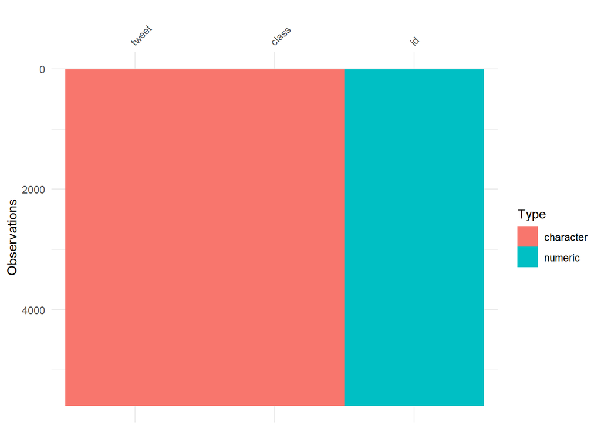

```r
visdat::vis_dat(d_hate, warn_large_data = FALSE)
```

Im Datensatz gibt es keine fehlenden Werte. Sowohl `tweet` als auch `class` sind character-Variablen. Für die Klassifikation würde es eventuell Sinn machen `class` in eine factor Variable umzuwandeln.

### 3.3 Anteile der Faktorstufen der AV betrachten

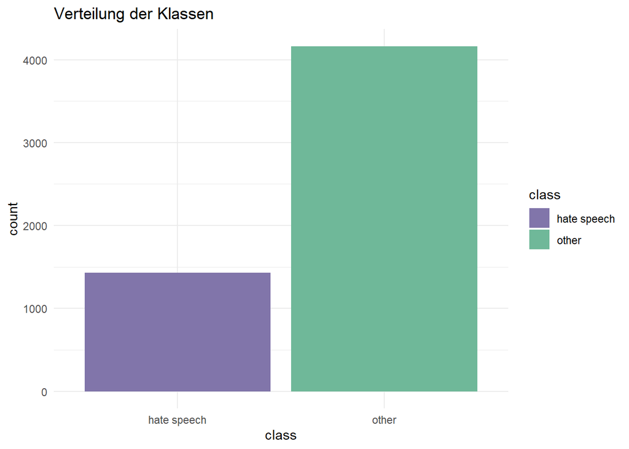

```r
ggplot(d_hate, aes(x = class, fill = class)) +
  geom_bar() +
  labs(title = "Verteilung der Klassen") +
  scale_fill_tableau("Nuriel Stone") +
  theme_minimal()
```

```r
d_hate |>
  count(class == "other") |>
  mutate(Anteil = n/sum(n))
```

| class == "other" | n | Anteil |
| --- | --- | --- |
| FALSE | 1430 | 0.2556767 |
| TRUE | 4163 | 0.7443233 |

Ca. 25 % der Daten sind der Klasse hate speech zugeordnet. Zum Trainieren der Modelle wäre ein höherer Anteil möglicherweise besser, aber diese Verteilung ist auf jeden Fall realistischer.

### 3.2 Tokenisierung

```r
tweets <- hate2 %>%
  unnest_tokens(word, textclean)
tweets <- tweets %>%
  anti_join(stop_words)
```

Entfernen des Worts “rt”, welches für retweet steht.

```r
# Das zu entfernende Wort
word_to_remove <- "rt"

tweets3 <- anti_join(tweets, data.frame(word = word_to_remove), by = "word")
```

### 3.3 Häufigste Wörter

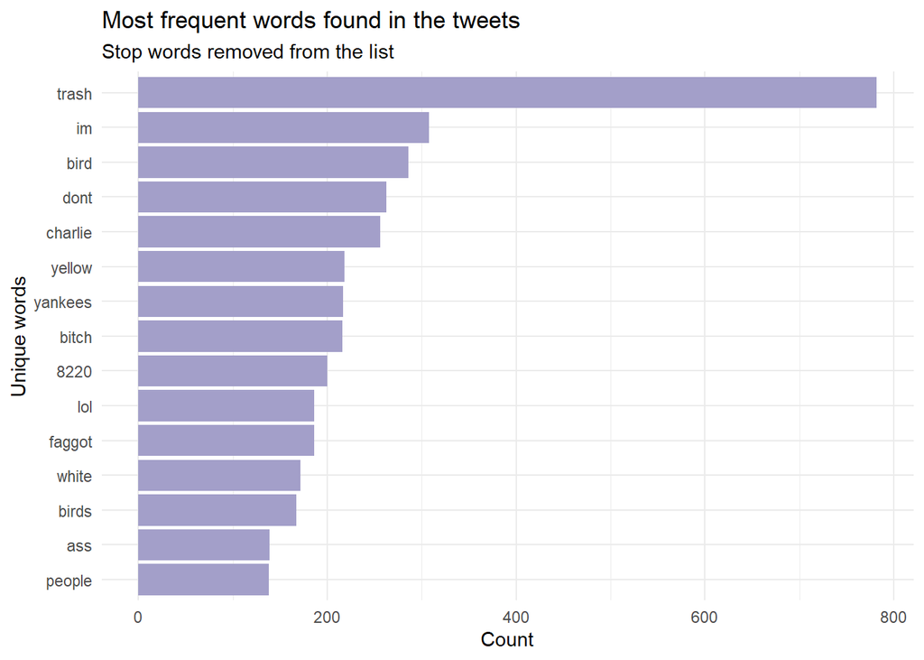

```r
tweets3 %>%
  count(word, sort = TRUE) %>%
  top_n(15) %>%
  mutate(word = reorder(word, n)) %>%
  ggplot(aes(x = word, y = n)) +
  geom_col(fill = "#A39FC9FF") +
  xlab(NULL) +
  coord_flip() +
  labs(y = "Count",
       x = "Unique words",
       title = "Most frequent words found in the tweets",
       subtitle = "Stop words removed from the list") +
  theme_minimal()
```

Das mit Abstand am häufigsten verwendete Wort ist trash. Dieses kommt fast 800 Mal in den Daten vor, was vielleicht darauf zu schließen ist, dass es sowohl im negativen, neutralen als auch im hate speech Kontext vorkommen kann. Es könnte nämlich dabei um trash cans, trash talking oder um trash als Beleidung für Personen gehen.

### 3.4 Wortwolken

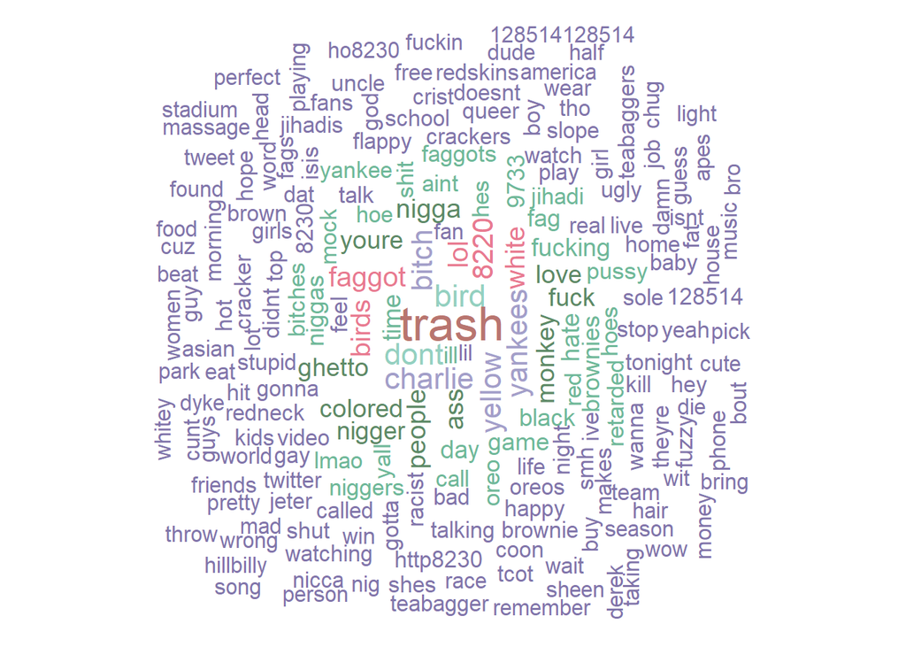

```r
set.seed(42)
wordcloud(tweets3$word, max.words = 200, min.freq=5, scale=c(2.2, 1), random.order=FALSE, rot.per=0.35, colors = colorsn)
```

Auch in der Wortwolke sieht man nochmal, dass trash das am häufigsten verwendete Wort ist, wobei einige Wörter vom plot darüber hier nicht auftauchen.

### 3.5 Sentimentanalyse

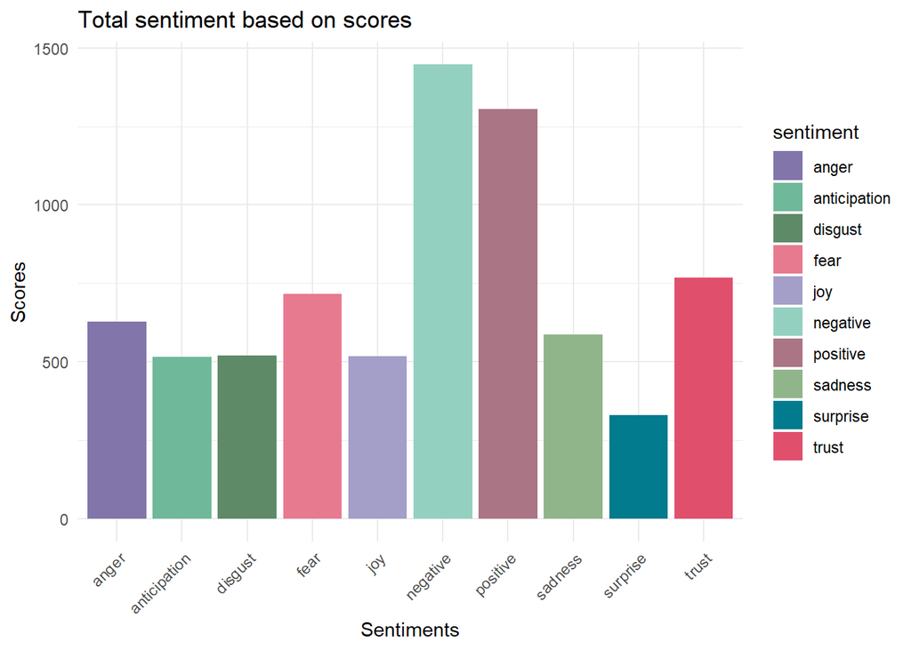

```r
# Converting tweets to ASCII to trackle strange characters
tweets2 <- iconv(tweets, from="UTF-8", to="ASCII", sub="")
# removing retweets, in case needed
tweets2 <-gsub("(RT|via)((?:\\b\\w*@\\w+)+)","",tweets)
# removing mentions, in case needed
tweets2 <-gsub("@\\w+","",tweets)
ew_sentiment<-get_nrc_sentiment((tweets2))
sentimentscores<-data.frame(colSums(ew_sentiment[,]))
names(sentimentscores) <- "Score"
sentimentscores <- cbind("sentiment"=rownames(sentimentscores),sentimentscores)
rownames(sentimentscores) <- NULL
ggplot(data=sentimentscores,aes(x=sentiment,y=Score))+
  geom_bar(aes(fill=sentiment),stat = "identity")+
  theme(legend.position="none")+
  xlab("Sentiments")+ylab("Scores")+
  ggtitle("Total sentiment based on scores")+
  theme_minimal() +
  theme(axis.text.x = element_text(angle = 45, hjust = 1)) +
  scale_fill_manual(values = colorsn)
```

Es gibt mehr negativ gestimmte Tweets als positive, aber der Unterschied ist nicht so hoch. Die stärkste Stimmung scheint `trust`, also Vertrauen, zu sein, dicht gefolgt von `fear`. Das niedrigste Sentiment ist `suprise`. Jetzt wäre es noch interessant zu wissen wie sich die Sentimentanalyse noch jeweils für die beiden Klassen unterscheidet.

FÜr die Klasse hate speech:

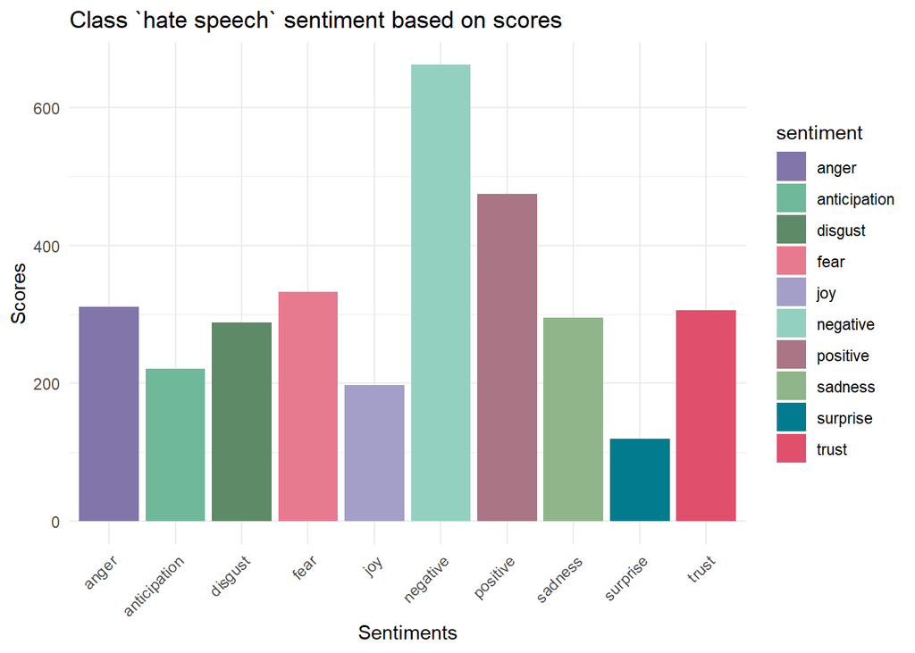

```r
tweetsh <- tweets |>
  filter(classc == "hate speech")


tweetsh1 <- iconv(tweetsh, from="UTF-8", to="ASCII", sub="")
tweetsh1 <-gsub("(RT|via)((?:\\b\\w*@\\w+)+)","",tweetsh)
tweetsh1 <-gsub("@\\w+","",tweetsh)
ew_sentimenth<-get_nrc_sentiment((tweetsh1))
sentimentscoresh<-data.frame(colSums(ew_sentimenth[,]))
names(sentimentscoresh) <- "Score"
sentimentscoresh <- cbind("sentiment"=rownames(sentimentscoresh),sentimentscoresh)
rownames(sentimentscoresh) <- NULL
ggplot(data=sentimentscoresh,aes(x=sentiment,y=Score))+
  geom_bar(aes(fill=sentiment),stat = "identity")+
  theme(legend.position="none")+
  xlab("Sentiments")+ylab("Scores")+
  ggtitle("Class `hate speech` sentiment based on scores")+
  theme_minimal() +
  theme(axis.text.x = element_text(angle = 45, hjust = 1)) +
  scale_fill_manual(values = colorsn)
```

Wie zu erwarten mehr negative als positive Sentiments, jedoch ist `positive` immer noch erstaunlich hoch dafür, dass es hate speech ist. Insgesamt sind die negativen Sentimente wie `anger`, `fear`, `disgust` und `sadness` höher als die positiven, jedoch hätte ich gerade was `anger` und `distgust` angeht viel höhere Werte im Vergleich erwartet.

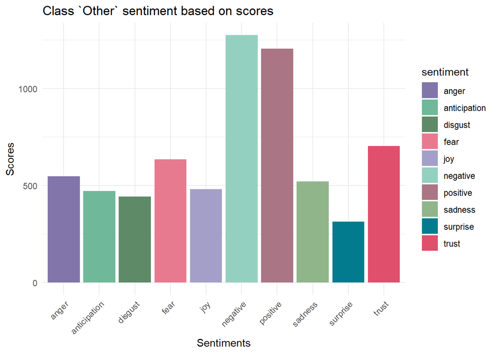

```r
tweetso <- tweets |>
  filter(classc == "other")


tweetso1 <- iconv(tweetso, from="UTF-8", to="ASCII", sub="")
tweetso1 <-gsub("(RT|via)((?:\\b\\w*@\\w+)+)","",tweetso)
tweetso1 <-gsub("@\\w+","",tweetso)
ew_sentimento<-get_nrc_sentiment((tweetso1))
sentimentscoreso<-data.frame(colSums(ew_sentimento[,]))
names(sentimentscoreso) <- "Score"
sentimentscoreso <- cbind("sentiment"=rownames(sentimentscoreso),sentimentscoreso)
rownames(sentimentscoreso) <- NULL
ggplot(data=sentimentscoreso,aes(x=sentiment,y=Score))+
  geom_bar(aes(fill=sentiment),stat = "identity")+
  theme(legend.position="none")+
  xlab("Sentiments")+ylab("Scores")+
  ggtitle("Class `Other` sentiment based on scores")+
  theme_minimal() +
  theme(axis.text.x = element_text(angle = 45, hjust = 1)) +
  scale_fill_manual(values = colorsn)
```

Auch bei der Klasse other überwiegen negative Sentiments, jedoch nicht so stark. Den höchsten Score hat `trust`, dicht gefolgt von `fear`. Insgesamt ist die Verteilung sehr ähnlich zu den Scores von allen tweets.

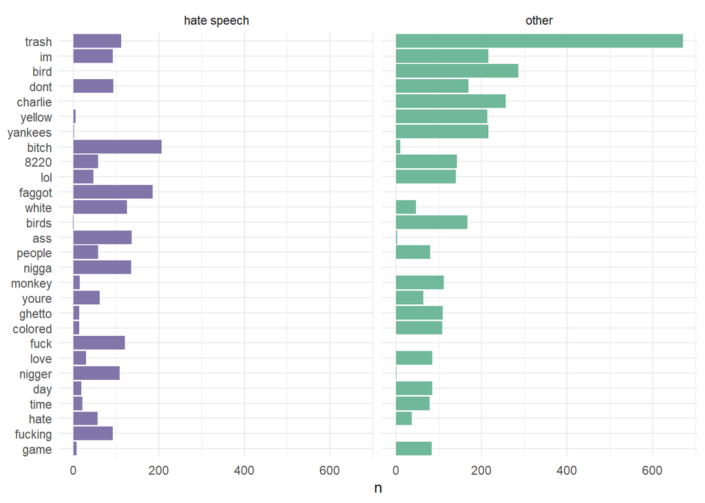

```r
foo <- tweets3 %>%
  group_by(word, classc) %>%
  count()

bar <- tweets3 %>%
  group_by(word) %>%
  count() %>%
  rename(all = n)

foo %>%
  left_join(bar, by = "word") %>%
  arrange(desc(all)) %>%
  head(50) %>%
  ungroup() %>%
  ggplot(aes(reorder(word, all, FUN = min), n, fill = classc)) +
  geom_col(witdh = 10) +
  xlab(NULL) +
  coord_flip() +
  facet_wrap(~ classc) +
  scale_fill_tableau("Nuriel Stone") +
  theme_minimal() +
  theme(legend.position = "none")
```

Hier wird das Vorkommen der häufigsten Wörter in den beiden Klassen verglichen. Gut zu sehen ist dabei, dass manche Wörter erst im Kontext eine negative Bedeutung bekommen, wie z.B. trash oder white. Diese können sowohl der sachlichen Beschreibung als auch zur Beleidigung dienen.

### 3.7 Textlänge in Abhängigkeit der Klasse

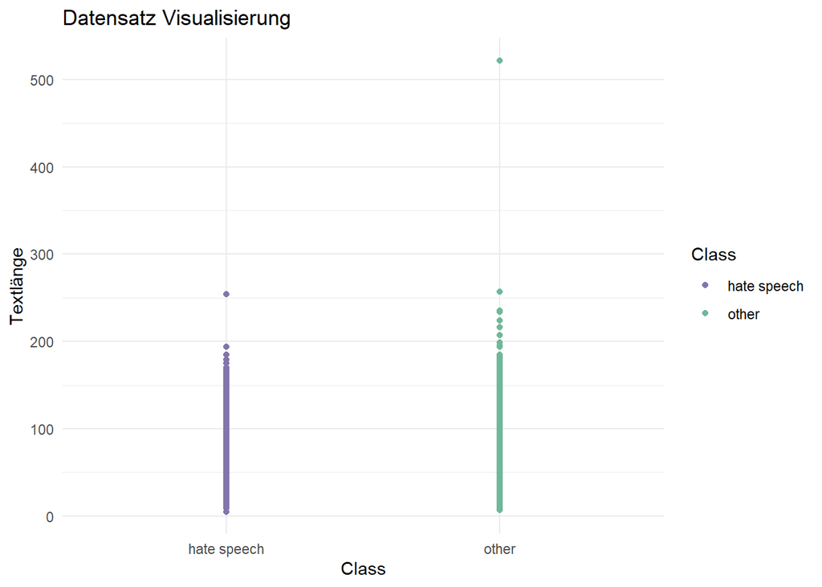

```r
hate1 <-
  d_hate |>
  mutate(text_length = str_length(tweet))

ggplot(hate1, aes(x = class, y = text_length, color = class)) +
  geom_point() +
  labs(title = "Datensatz Visualisierung",
       x = "Class",
       y = "Textlänge",
       color = "Class") +
  scale_color_tableau("Nuriel Stone") +
  theme_minimal()
```

Die Klasse `other` besitzt mehr Ausreißer nach oben hin, aber sonst scheint es keine großen Unterschiede zwischen beiden Klassen zu geben.

### 3.8 Histogramm der Textlänge

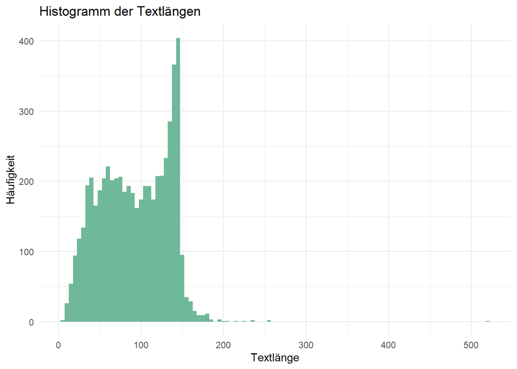

```r
ggplot(hate1, aes(x = text_length)) +
  geom_histogram(binwidth = 5, fill = "#6FB899FF", ) +
  scale_fill_tableau("Nuriel Stone") +
  labs(title = "Histogramm der Textlängen",
       x = "Textlänge",
       y = "Häufigkeit") +
  theme_minimal()
```

Die Textlänge ist etwas linkschief verteilt, wobei ein Großteil der tweets unter 150 Zeichen hat. Die meisten Tweets wurden jedoch mit knapp 150 Zeichen verfasst. Dies lässt sich möglicherweise durch das Alter der Daten erklären, denn bis 2017 waren Tweets auf 140 Zeichen begrenzt und danach waren erst mehr (aktuell 280) erlaubt.

### 3.9 Boxplot

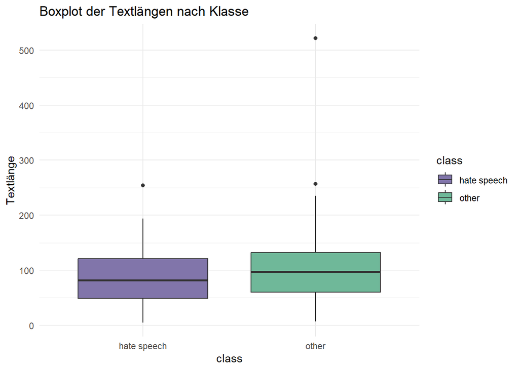

```r
ggplot(hate1, aes(x = class, y = text_length, fill = class)) +
  geom_boxplot() +
  labs(title = "Boxplot der Textlängen nach Klasse", x = "class", y = "Textlänge", fill = "class")+
  scale_fill_tableau("Nuriel Stone") +
  theme_minimal()
```

```r
hate1 |>
  group_by(class) |>
  summarise(mean(text_length))
```

| class | mean(text_length) |
| --- | --- |
| hate speech | 84.58671 |
| other | 94.85011 |

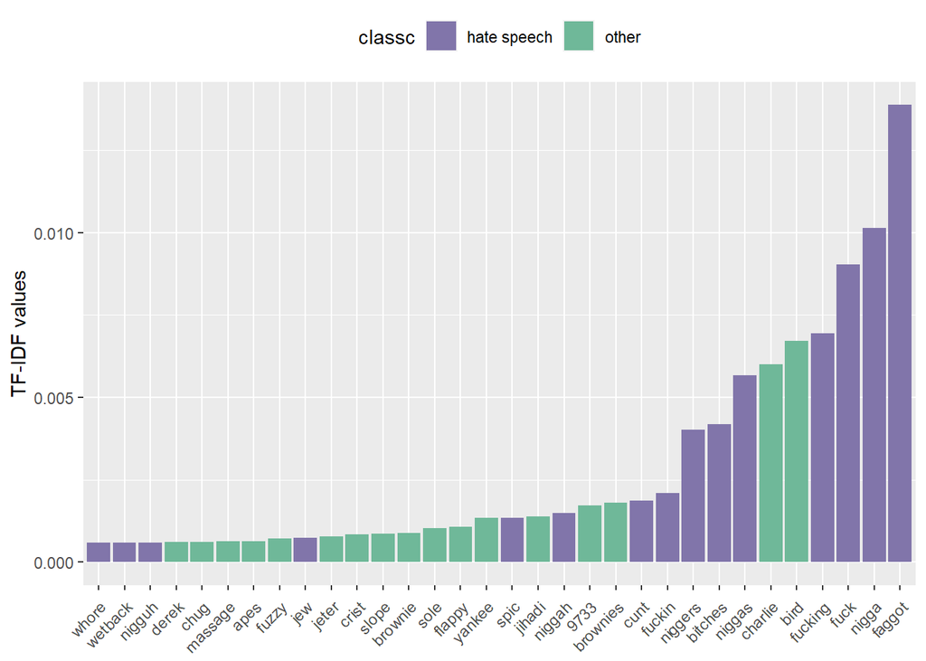

```r
frequency2 <-tweets3 %>%
  count(classc, word)

tf_idf <- frequency2 %>%
  bind_tf_idf(word, classc, n)

tf_idf %>%
  arrange(desc(tf_idf)) %>%
  mutate(word = factor(word, levels = rev(unique(word)))) %>%
  top_n(30, tf_idf) %>%
  ggplot(aes(word, tf_idf, fill = classc)) +
  geom_col() +
  labs(x = NULL, y = "TF-IDF values") +
  theme(legend.position = "top", axis.text.x  = element_text(angle=45, hjust=1, vjust=0.9)) +
  scale_fill_manual(values = colorsn)
```

TF-IDF gibt die Häufigkeit eines Wortes in einem spezifischen Kontext (also einer Klasse) innerhalb einer größeren Textsammlung (also alle Klassen) an. Dies ermöglicht es uns, Wörter zu identifizieren, die charakteristisch für eine bestimmte Klasse sind.

Für die Klassifizierung von hate speech sind vor allem Beleidigungen wichtig, während other scheinbar neutrale Wörter enthält.

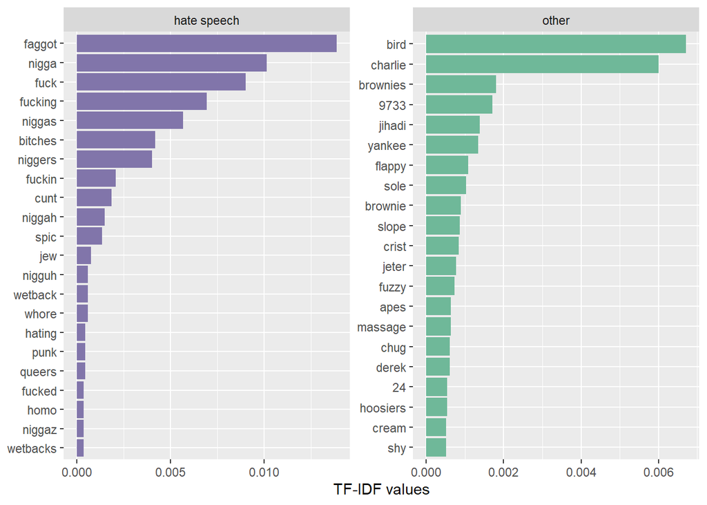

```r
tf_idf %>%
  arrange(desc(tf_idf)) %>%
  mutate(word = factor(word, levels = rev(unique(word)))) %>%
  group_by(classc) %>%
  top_n(20, tf_idf) %>%
  ungroup() %>%
  ggplot(aes(word, tf_idf, fill = classc)) +
  geom_col() +
  labs(x = NULL, y = "tf-idf") +
  theme(legend.position = "none") +
  facet_wrap(~ classc, ncol = 3, scales = "free") +
  coord_flip() +
  labs(y = "TF-IDF values") +
  scale_fill_manual(values = colorsn)
```

Hier sind nochmal die Wörter mit den höchsten TF-IDF-Werten nach Klasse aufgelistet. Auch hier ist gut zu erkennen, dass bei hate speech vor allem rassistische, diskriminierende und sexistische Beleidigungen verwendet werden, während bei other scheinbar wahllos Wörter auftauchen.

### 3.11 Bigrams

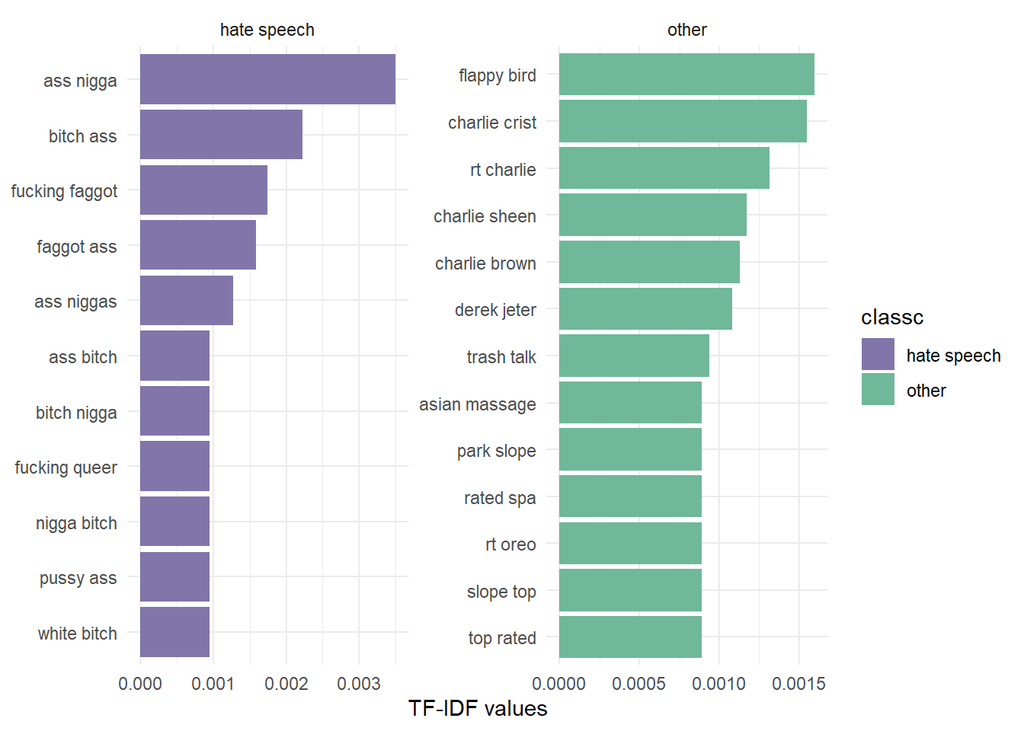

```r
tweets4 <- hate2 %>% dplyr::select(classc, textclean) %>% unnest_tokens(bigram, textclean, token = "ngrams", n = 2)

bi_sep <- tweets4 %>%
  separate(bigram, c("word1", "word2"), sep = " ")

bi_filt <- bi_sep %>%
  filter(!word1 %in% stop_words$word) %>%
  filter(!word2 %in% stop_words$word)

# for later
bigram_counts <- bi_filt %>%
  count(word1, word2, sort = TRUE)

tweets4 <- bi_filt %>%
  unite(bigram, word1, word2, sep = " ")

t2_tf_idf <- tweets4 %>%
  count(classc, bigram) %>%
  bind_tf_idf(bigram, classc, n) %>%
  arrange(desc(tf_idf))

t2_tf_idf %>%
  arrange(desc(tf_idf)) %>%
  mutate(bigram = factor(bigram, levels = rev(unique(bigram)))) %>%
  group_by(classc) %>%
  top_n(10, tf_idf) %>%
  ungroup() %>%
  ggplot(aes(bigram, tf_idf, fill = classc)) +
  geom_col() +
  labs(x = NULL, y = "TF-IDF values") +
  theme(legend.position = "none") +
  facet_wrap(~ classc, ncol = 3, scales = "free") +
  coord_flip() +
  theme_minimal() +
  scale_fill_manual(values = colorsn)
```

Auch bei den TF-IDF-Werte für die Bigramme ist eindeutig zu essen, wie relevant Beleidigungen zur Erkennung von hate speech sind. Oftmals wurden hier einfach nur Beleidigungen kombiniert, während bei other entweder über Personen oder auch assiatische Massagen geredet wird.

### 3.12 Bigram-Netz

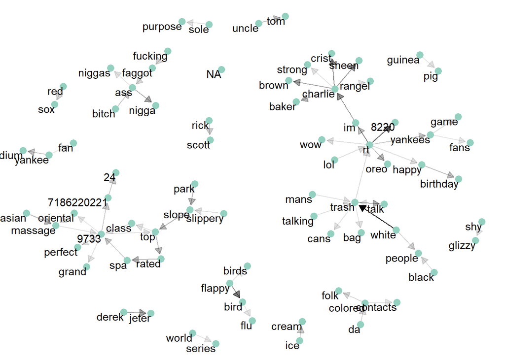

```r
bigram_graph <- bigram_counts %>%
  filter(n > 6) %>%
  graph_from_data_frame()
set.seed(1234)

a <- grid::arrow(type = "closed", length = unit(.1, "inches"))

ggraph(bigram_graph, layout = "fr") +
  geom_edge_link(aes(edge_alpha = n), show.legend = FALSE,
                 arrow = a, end_cap = circle(.07, 'inches')) +
  geom_node_point(color = "#94D0C0FF", size = 3) +
  geom_node_text(aes(label = name), vjust = 1, hjust = 1) +
  theme_void()
```

### 3.13 Negierte Begriffe

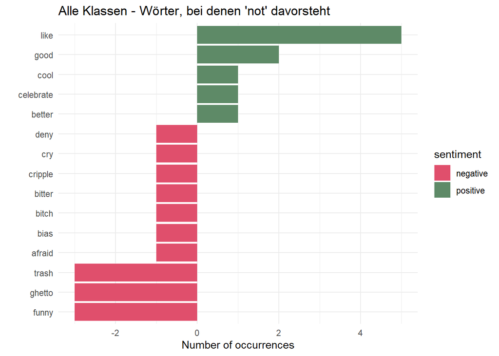

```r
bi_sep <- hate2 %>%
  dplyr::select(classc, textclean) %>%
  unnest_tokens(bigram, textclean, token = "ngrams", n = 2) %>%
  separate(bigram, c("word1", "word2"), sep = " ")

p1 <- bi_sep %>%
  filter(word1 == "not") %>%
  inner_join(get_sentiments("bing"), by = c(word2 = "word")) %>%
  count(word1, word2, sentiment, sort = TRUE) %>%
  ungroup() %>%
  arrange(desc(abs(n))) %>%
  head(15) %>%
  mutate(n = if_else(sentiment == "positive", n, -n)) %>%
  mutate(word2 = reorder(word2, n)) %>%
  ggplot(aes(word2, n, fill = sentiment)) +
  geom_col(show.legend = TRUE) +
  xlab("") +
  ylab("Number of occurrences") +
  coord_flip() +
  theme(plot.title = element_text(size=11)) +
  ggtitle("Alle Klassen - Wörter, bei denen 'not' davorsteht") +
  scale_fill_manual(values = c("#E04F6C", "#5E8A67FF")) +
  theme_minimal()
print(p1)
```

Anscheinend gibt es mehr negative Wörter, die mit einem ‘not’ verneint wurden. Interessanterweise wird das Wort funny auch als negativ gewertet, was nicht wirklich Sinn macht. Im Zusammenhang mit ‘not’ ist es natürlich sinnvoll, es als negativ einzuordnen.

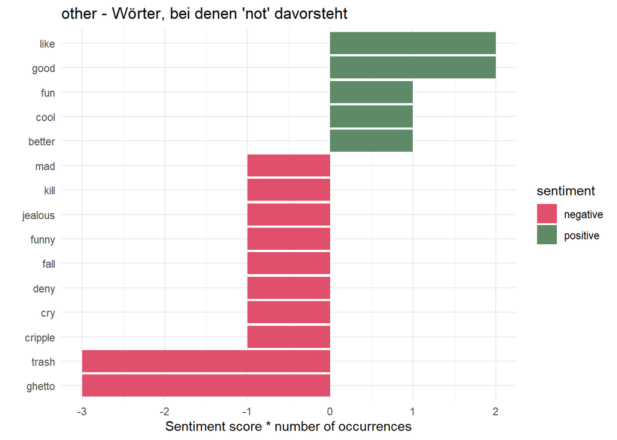

```r
p2 <- bi_sep %>%
  filter(classc == "other") %>%
  filter(word1 == "not") %>%
  inner_join(get_sentiments("bing"), by = c(word2 = "word")) %>%
  count(word1, word2, sentiment, sort = TRUE) %>%
  ungroup() %>%
  arrange(desc(abs(n))) %>%
  head(15) %>%
  mutate(n = if_else(sentiment == "positive", n, -n)) %>%
  mutate(word2 = reorder(word2, n)) %>%
  ggplot(aes(word2, n, fill = sentiment)) +
  geom_col(show.legend = TRUE) +
  xlab("") +
  ylab("Sentiment score * number of occurrences") +
  coord_flip() +
  theme(plot.title = element_text(size=11)) +
  ggtitle("other - Wörter, bei denen 'not' davorsteht")  +
  scale_fill_manual(values = c("#E04F6C", "#5E8A67FF")) +
  theme_minimal()
print(p2)
```

Auch in der Klasse other gibt es mehr negative als positive Wörter. Dies war uns ja schon vorher aus der Sentimentanalyse bewusst, deswegen ist es hier nocheinmal interessant zu sehen, dass die negative Bedeutung dieser Wörter durch das ‘not’ aufgehoben wird. Zudem taucht auch hier das Wort trash auf.

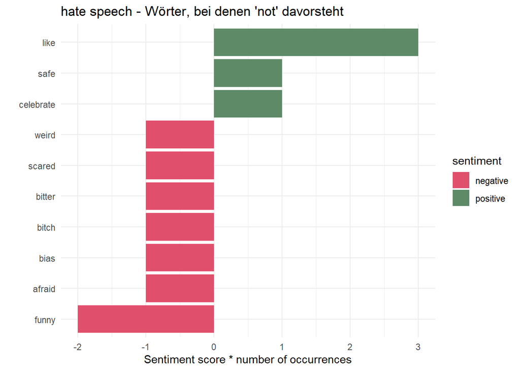

```r
p3 <- bi_sep %>%
  filter(classc == "hate speech") %>%
  filter(word1 == "not") %>%
  inner_join(get_sentiments("bing"), by = c(word2 = "word")) %>%
  count(word1, word2, sentiment, sort = TRUE) %>%
  ungroup() %>%
  arrange(desc(abs(n))) %>%
  head(15) %>%
  mutate(n = if_else(sentiment == "positive", n, -n)) %>%
  mutate(word2 = reorder(word2, n)) %>%
  ggplot(aes(word2, n, fill = sentiment)) +
  geom_col(show.legend = TRUE) +
  xlab("") +
  ylab("Sentiment score * number of occurrences") +
  coord_flip() +
  theme(plot.title = element_text(size=11)) +
  ggtitle("hate speech - Wörter, bei denen 'not' davorsteht")  +
  scale_fill_manual(values = c("#E04F6C", "#5E8A67FF")) +
  theme_minimal()

print(p3)
```

Für die Klasse hate speech gibt es auch mehr negative als positive Wörter. Dies war uns ebenfalls schon vorher aus der Sentimentanalyse bewusst, deswegen ist es hier nocheinmal interessant zu sehen, dass die negative Bedeutung dieser Wörter durch das ‘not’ aufgehoben wird. Was hier aber auffällt, vor allem im Vergleich zur anderen Klasse, ist dass hier viele negativen Wörter gar nicht so schlimm sind, also z.B. afraid oder bitter. In der anderen Klasse gab es dagegen die Wörter kill, jealous und cripple. Also wurden dort schlimmere Wörter durch ein ‘not’ aufgehoben, während bei hate speech nur meiner Meinung nach schwach negative Begriffe negiert werden.

### 3.14 Themenanalyse

```r
freq <-tweets %>%
  count(id, word)

t1_tm <- cast_dtm(freq, id, word, n)
t1_tm
```

```
<<DocumentTermMatrix (documents: 5592, terms: 12768)>>
Non-/sparse entries: 39386/71359270
Sparsity           : 100%
Maximal term length: 81
Weighting          : term frequency (tf)
```

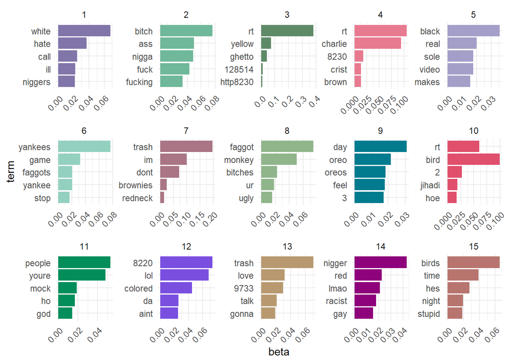

```r
t1_lda <- LDA(t1_tm, k = 15, control = list(seed = 1234))

t1_topics <- tidy(t1_lda, matrix = "beta")

t1_topics %>%
  group_by(topic) %>%
  top_n(5, beta) %>%
  ungroup() %>%
  arrange(topic, -beta) %>%
  mutate(term = reorder(term, beta)) %>%
  ggplot(aes(term, beta, fill = factor(topic))) +
  geom_col(show.legend = FALSE) +
  facet_wrap(~ topic, scales = "free", ncol = 5)  +
  coord_flip() +
  scale_fill_manual(values = colorsn) +
  theme_minimal() +
  theme(axis.text.x = element_text(angle = 45, hjust = 1))
```

Die Themenfelder lassen sich hier in Beleidigungen und zufällige Themen einteilen. Gerade unter den Beleidigungen gibt es nochmal Abstufungen zwischen “allgemeinen” Beleidigungen und rassistischen. Bei den allgemeinen Themen geht es unter anderem um die yankees, positive Gefühle und Vögel. So wirklich etwas aussagen tut aber keiner dieser Themenfelder, dafür sind sie sich gerade bei den Beleidigungen einfach viel zu ähnlich.

## 4. tidymodels

### 4.1 Rezept erstellen

Verschiedene Rezepte mit unterschiedlicher Vorverarbeitung, um am Ende das beste zu finden.

```r
# Rezept 1
rec1 <-
  recipe(class ~ ., data = train) |>
  update_role(id, new_role = "id")  |>
  update_role(tweet, new_role = "ignore") |>
  step_text_normalization(tweet) |>
  step_mutate(n_schimpf = get_sentiment(tweet,
                                    method = "custom",
                                    lexicon = Insults)) |>
  step_mutate(n_emo = get_sentiment(tweet,
                                    method = "nrc",
                                    language = "english"))  |>
  step_tokenize(tweet) %>%
  step_stopwords(tweet, language = "en", stopword_source = "snowball", keep = FALSE) |>
  step_tokenfilter(tweet, max_tokens = 1e2)

tidy(rec1)
```

| number | operation | type | trained | skip | id |
| --- | --- | --- | --- | --- | --- |
| 1 | step | text_normalization | FALSE | FALSE | text_normalization_eD6Uv |
| 2 | step | mutate | FALSE | FALSE | mutate_w2lrd |
| 3 | step | mutate | FALSE | FALSE | mutate_SoVUR |
| 4 | step | tokenize | FALSE | FALSE | tokenize_a3i8t |
| 5 | step | stopwords | FALSE | FALSE | stopwords_ylt9c |
| 6 | step | tokenfilter | FALSE | FALSE | tokenfilter_9UjlV |

```r
d_baked1 <- prep(rec1) |> bake(new_data = NULL)
sum(is.na(d_baked1))
```

```
[1] 0
```

```r
# Rezept 2
rec2 <-
  recipe(class ~ ., data = train) |>
  update_role(id, new_role = "id")  |>
  update_role(tweet, new_role = "ignore") |>
  step_text_normalization(tweet) |>
  step_mutate(n_schimpf = get_sentiment(tweet,  # aus `syuzhet`
                                    method = "custom",
                                    lexicon = Insults)) |>
  step_mutate(n_emo = get_sentiment(tweet,  # aus `syuzhet`
                                    method = "nrc",
                                    language = "englisch"))  |>
  step_tokenize(tweet) %>%
  step_stopwords(tweet, language = "en", stopword_source = "snowball", keep = FALSE) |>
  step_tokenfilter(tweet, max_tokens = 1e3) |>
  step_tfidf(tweet)

tidy(rec2)
```

| number | operation | type | trained | skip | id |
| --- | --- | --- | --- | --- | --- |
| 1 | step | text_normalization | FALSE | FALSE | text_normalization_gs6RE |
| 2 | step | mutate | FALSE | FALSE | mutate_qv0pp |
| 3 | step | mutate | FALSE | FALSE | mutate_OnGoL |
| 4 | step | tokenize | FALSE | FALSE | tokenize_uBwNq |
| 5 | step | stopwords | FALSE | FALSE | stopwords_8JLze |
| 6 | step | tokenfilter | FALSE | FALSE | tokenfilter_aHBDr |
| 7 | step | tfidf | FALSE | FALSE | tfidf_dctft |

```r
d_baked2 <- prep(rec2) |> bake(new_data = NULL)
sum(is.na(d_baked2))
```

```
[1] 0
```

### 4.2 Kreuzvalidierung

```r
set.seed(42)
cv_scheme <- vfold_cv(train,
  v = 5,
  repeats = 2,
  strata = class)
```

### 4.3 Modelle

```r
# Baum
mod_tree <-
  decision_tree(cost_complexity = tune(),
  tree_depth = tune(),
  mode = "classification")

# Random Forest
mod_rf <-
  rand_forest(mtry = tune(),
  min_n = tune(),
  trees = 1000,
  mode = "classification") %>%
  set_engine("ranger", num.threads = 4)

# XGBoost

mod_boost <- boost_tree(
  mode = "classification",
  engine = "xgboost",
  mtry = tune(),
  trees = tune(),
  min_n = tune()
)


# logistische Regression
mod_logreg <- logistic_reg(
              mode = "classification",
              engine = "glm",
              penalty = 1)
```

### 4.4 Workflows erstellen

Die Zahlenbenennung der Workflows ist immer die Kombination aus welchem Modell (1-4) und welches Rezept (1-2) Ich habe mich gezielt gegen Workflowsets entschieden, da die Rechenzeit für meinen Computer dafür immer sehr lange dauert.

```r
# Rezept 1 mit decision tree
workflow11 <-
  workflow() |>
  add_model(mod_tree) |>
  add_recipe(rec1)

# Rezept 2 mit decision tree
workflow12 <-
  workflow() |>
  add_model(mod_tree) |>
  add_recipe(rec2)

# Rezept 1 mit random forest
workflow21 <-
  workflow() |>
  add_model(mod_rf) |>
  add_recipe(rec1)

# Rezept 2 mit random forest (dauert viel zu lange)
# workflow22 <-
  #workflow() |>
  #add_model(mod_rf) |>
  #add_recipe(rec2)

# Rezept 1 mit xgboost
workflow31 <-
  workflow() |>
  add_model(mod_boost) |>
  add_recipe(rec1)

# Rezept 2 mit xgboost (dauert viel zu lange)
#workflow32 <-
  #workflow() |>
  #add_model(mod_boost) |>
  #add_recipe(rec2)

# Rezept 1 mit logistischer Regression
workflow41 <-
  workflow() |>
  add_model(mod_logreg) |>
  add_recipe(rec1)

# Rezept 2 mit logistischer Regression (Modell läuft leider nicht)
#workflow42 <-
  #workflow() |>
  #add_model(mod_logreg) |>
  #add_recipe(rec2)
```

### 4.5 Tuning

Bestes Workflowset

```r
# tune11
set.seed(42)
tic()
tune11 <-
  tune_grid(object = workflow11,
            resamples = cv_scheme,
            grid = 10,
            control = control_grid(save_workflow = TRUE))
toc()
```

```
493.11 sec elapsed
```

```r
# tune12
set.seed(42)
tic()
tune12 <-
  tune_grid(object = workflow12,
            resamples = cv_scheme,
            grid = 10,
            control = control_grid(save_workflow = TRUE))
toc()
```

```
971.25 sec elapsed
```

```r
# tune21
set.seed(42)
tic()
tune21 <-
  tune_grid(object = workflow21,
            resamples = cv_scheme,
            grid = 10,
            control = control_grid(save_workflow = TRUE))
```

```
i Creating pre-processing data to finalize unknown parameter: mtry
```

```r
toc()
```

```
456.7 sec elapsed
```

```r
#tune31
set.seed(42)
tic()
tune31 <-
  tune_grid(object = workflow31,
            resamples = cv_scheme,
            grid = 10,
            control = control_grid(save_workflow = TRUE))
```

```
i Creating pre-processing data to finalize unknown parameter: mtry
```

```r
toc()
```

```
569.36 sec elapsed
```

```r
#tune41
set.seed(42)
tic()
tune41 <-
  tune_grid(object = workflow41,
            resamples = cv_scheme,
            grid = 10,
            control = control_grid(save_workflow = TRUE))
toc()
```

```
133.95 sec elapsed
```

### 4.6 Modellvergelich

```r
# mit Rezept 6
tune11 |> collect_metrics()
```

| cost_complexity | tree_depth | .metric | .estimator | mean | n | std_err | .config |
| --- | --- | --- | --- | --- | --- | --- | --- |
| 1.442528e-10 | 1 | accuracy | binary | 0.7650865 | 10 | 0.001957094 | Preprocessor1_Model01 |
| 1.442528e-10 | 1 | roc_auc | binary | 0.5676181 | 10 | 0.003139741 | Preprocessor1_Model01 |
| 1.532098e-02 | 12 | accuracy | binary | 0.7649748 | 10 | 0.001979662 | Preprocessor1_Model02 |
| 1.532098e-02 | 12 | roc_auc | binary | 0.5671869 | 10 | 0.003292674 | Preprocessor1_Model02 |
| 1.027400e-05 | 13 | accuracy | binary | 0.7698930 | 10 | 0.001861094 | Preprocessor1_Model03 |
| 1.027400e-05 | 13 | roc_auc | binary | 0.6033445 | 10 | 0.006093747 | Preprocessor1_Model03 |
| 5.884876e-07 | 4 | accuracy | binary | 0.7689989 | 10 | 0.001851399 | Preprocessor1_Model04 |
| 5.884876e-07 | 4 | roc_auc | binary | 0.6031124 | 10 | 0.006099248 | Preprocessor1_Model04 |
| 8.136045e-08 | 10 | accuracy | binary | 0.7698930 | 10 | 0.001861094 | Preprocessor1_Model05 |
| 8.136045e-08 | 10 | roc_auc | binary | 0.6033445 | 10 | 0.006093747 | Preprocessor1_Model05 |

[output cut: 10 more lines]

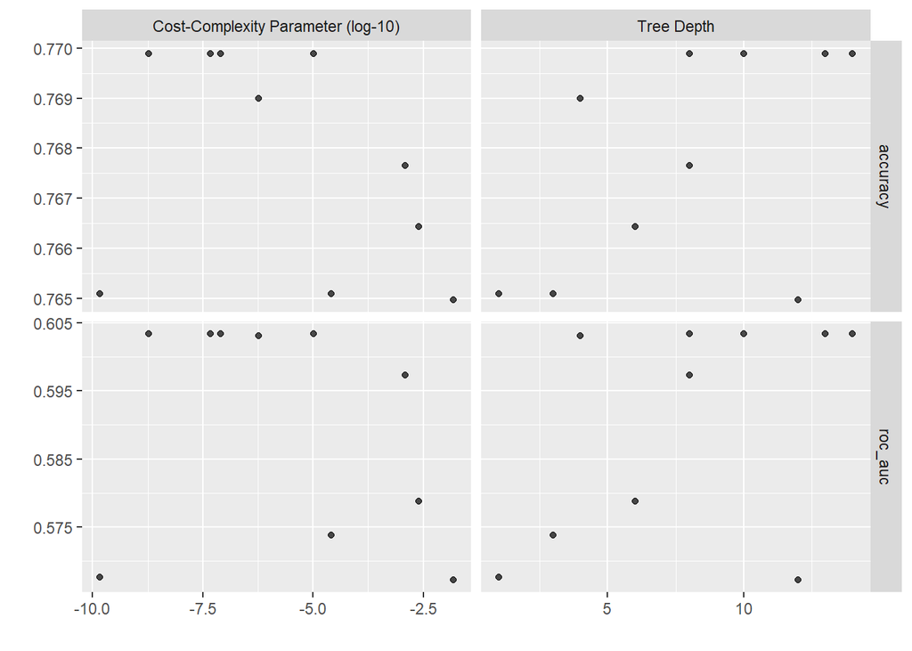

```r
autoplot(tune11)
```

```r
tune12 |> collect_metrics()
```

| cost_complexity | tree_depth | .metric | .estimator | mean | n | std_err | .config |
| --- | --- | --- | --- | --- | --- | --- | --- |
| 1.442528e-10 | 1 | accuracy | binary | 0.7727999 | 10 | 0.001435910 | Preprocessor1_Model01 |
| 1.442528e-10 | 1 | roc_auc | binary | 0.5570256 | 10 | 0.002532790 | Preprocessor1_Model01 |
| 1.532098e-02 | 12 | accuracy | binary | 0.8994172 | 10 | 0.002598859 | Preprocessor1_Model02 |
| 1.532098e-02 | 12 | roc_auc | binary | 0.8220543 | 10 | 0.004056502 | Preprocessor1_Model02 |
| 1.027400e-05 | 13 | accuracy | binary | 0.9064576 | 10 | 0.002394464 | Preprocessor1_Model03 |
| 1.027400e-05 | 13 | roc_auc | binary | 0.8341085 | 10 | 0.003904672 | Preprocessor1_Model03 |
| 5.884876e-07 | 4 | accuracy | binary | 0.8366118 | 10 | 0.002212503 | Preprocessor1_Model04 |
| 5.884876e-07 | 4 | roc_auc | binary | 0.6847367 | 10 | 0.003970916 | Preprocessor1_Model04 |
| 8.136045e-08 | 10 | accuracy | binary | 0.8891361 | 10 | 0.002638451 | Preprocessor1_Model05 |
| 8.136045e-08 | 10 | roc_auc | binary | 0.8014597 | 10 | 0.004052625 | Preprocessor1_Model05 |

[output cut: 10 more lines]

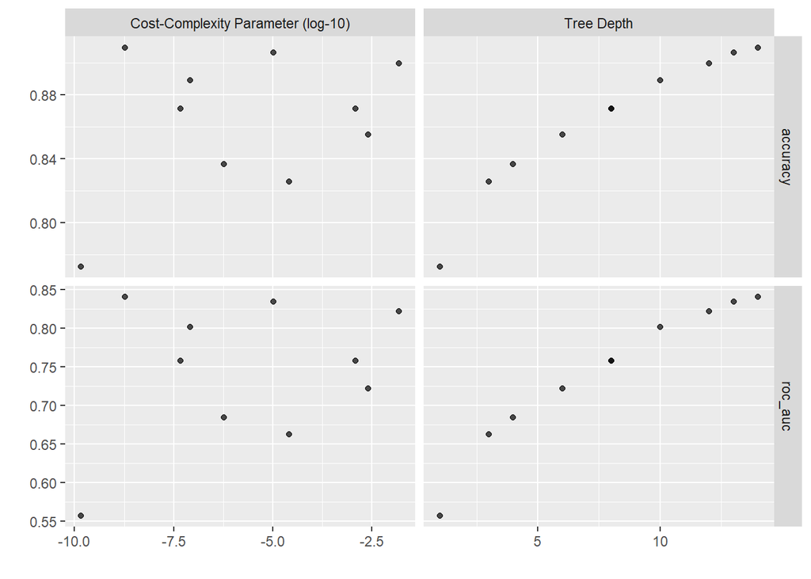

```r
autoplot(tune12)
```

```r
tune21 |> collect_metrics()
```

| mtry | min_n | .metric | .estimator | mean | n | std_err | .config |
| --- | --- | --- | --- | --- | --- | --- | --- |
| 1 | 3 | accuracy | binary | 0.7688872 | 10 | 0.001849181 | Preprocessor1_Model01 |
| 1 | 3 | roc_auc | binary | 0.6557016 | 10 | 0.004389830 | Preprocessor1_Model01 |
| 2 | 31 | accuracy | binary | 0.7693345 | 10 | 0.001707939 | Preprocessor1_Model02 |
| 2 | 31 | roc_auc | binary | 0.6548335 | 10 | 0.004495862 | Preprocessor1_Model02 |
| 2 | 34 | accuracy | binary | 0.7701166 | 10 | 0.001901398 | Preprocessor1_Model03 |
| 2 | 34 | roc_auc | binary | 0.6550414 | 10 | 0.004505147 | Preprocessor1_Model03 |
| 1 | 10 | accuracy | binary | 0.7691108 | 10 | 0.001880937 | Preprocessor1_Model04 |
| 1 | 10 | roc_auc | binary | 0.6555488 | 10 | 0.004423177 | Preprocessor1_Model04 |
| 1 | 27 | accuracy | binary | 0.7689990 | 10 | 0.001849735 | Preprocessor1_Model05 |
| 1 | 27 | roc_auc | binary | 0.6549843 | 10 | 0.004308179 | Preprocessor1_Model05 |

[output cut: 10 more lines]

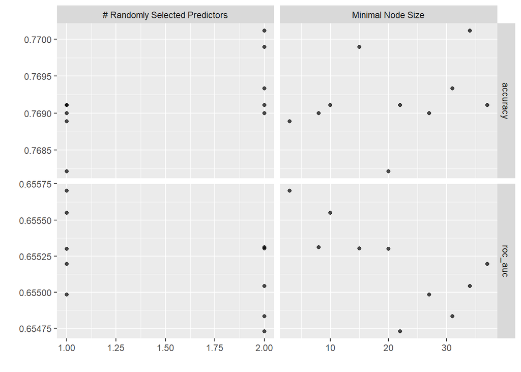

```r
autoplot(tune21)
```

```r
tune31 |> collect_metrics()
```

| mtry | trees | min_n | .metric | .estimator | mean | n | std_err | .config |
| --- | --- | --- | --- | --- | --- | --- | --- | --- |
| 1 | 100 | 4 | accuracy | binary | 0.7691109 | 10 | 0.001634340 | Preprocessor1_Model01 |
| 1 | 100 | 4 | roc_auc | binary | 0.6536345 | 10 | 0.004181102 | Preprocessor1_Model01 |
| 1 | 356 | 6 | accuracy | binary | 0.7704519 | 10 | 0.001842590 | Preprocessor1_Model02 |
| 1 | 356 | 6 | roc_auc | binary | 0.6548667 | 10 | 0.004046726 | Preprocessor1_Model02 |
| 1 | 1805 | 13 | accuracy | binary | 0.7704519 | 10 | 0.001842590 | Preprocessor1_Model03 |
| 1 | 1805 | 13 | roc_auc | binary | 0.6546973 | 10 | 0.004356507 | Preprocessor1_Model03 |
| 1 | 928 | 17 | accuracy | binary | 0.7682158 | 10 | 0.002788843 | Preprocessor1_Model04 |
| 1 | 928 | 17 | roc_auc | binary | 0.6550690 | 10 | 0.004253556 | Preprocessor1_Model04 |
| 1 | 1107 | 26 | accuracy | binary | 0.7669875 | 10 | 0.002381496 | Preprocessor1_Model05 |
| 1 | 1107 | 26 | roc_auc | binary | 0.6538479 | 10 | 0.004128131 | Preprocessor1_Model05 |

[output cut: 10 more lines]

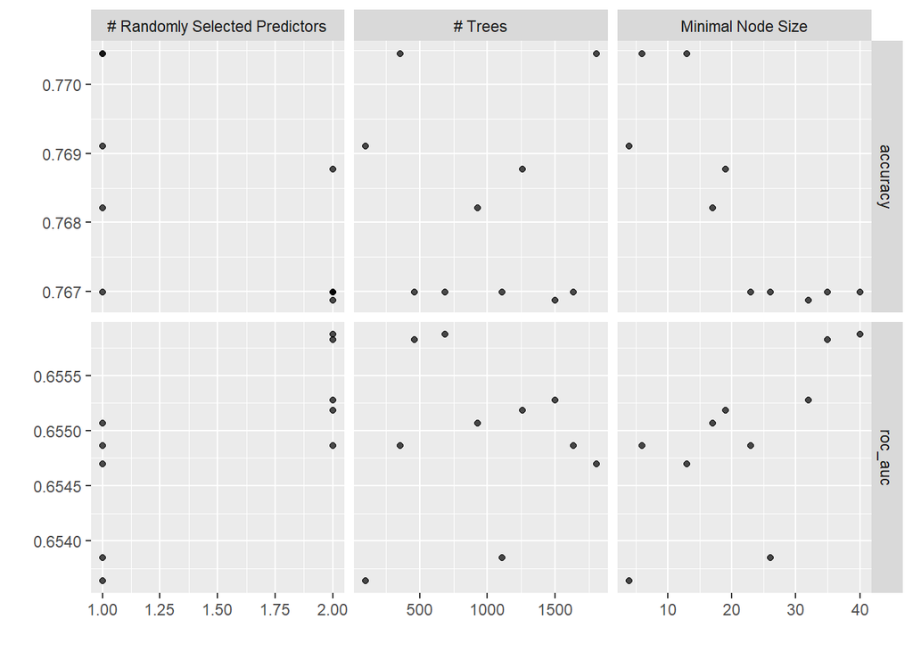

```r
autoplot(tune31)
```

```r
tune41 |> collect_metrics()
```

| .metric | .estimator | mean | n | std_err | .config |
| --- | --- | --- | --- | --- | --- |
| accuracy | binary | 0.7679931 | 10 | 0.001459084 | Preprocessor1_Model1 |
| roc_auc | binary | 0.6507851 | 10 | 0.003593218 | Preprocessor1_Model1 |